# *Suicidio, clima y desarrollo global.*

Fuentes de datos Biomédicas y Web semántica Grado de Ingeniería de la Salud

Ines Martos** *email* , **Paula Rastrilla** *email* **y Naiara Rodríguez** *email*.

13 diciembre, 2021

# 1. Introducción, objetivos y justificación

#### **Introducción**

A lo largo de este seminario, se pretende conocer la relación que existe entre *factores climáticos*, el *desarrollo socioeconómico* de las distintas naciones y los *índices de suicidio* publicados.

#### **Objetivos**

Inicialmente, se plantean una serie de objetivos de estudio, para los cuales se obtendrá respuesta tras el análisis correspondiente de los datos:

1. Evaluar el impacto de la temperatura media anual de un país en su tasa global de suicidio.
2. Estudiar la correlación entre los niveles de industrialización de un país (sector secundario) y sus tasas de emisión de CO2.
3. Comparación de las tasas de suicidio según los distintos sectores de producción de cada país y su relación con el sexo.
4. Análisis del aumento de emisiones de CO2 y su impacto en la temperatura media de una región/país.

#### **Justificación del tema**

La OMS define el suicidio como aquella acción mediante la cual un individuo se causa un daño a sí mismo, llegando a la muerte, sin tener en cuenta la intencionalidad y el conocimiento de los motivos. Sus características son la voluntariedad y la premeditación.

Algunos dicen que el cambio climático es la mayor amenaza de nuestra época, mientras que otros dicen que es un mito basado en ciencia dudosa.

¿Existe el cambio climático?¿de ser así tendría alguna relacion con las emisiones de CO2 que expulsamos a la atmósfera?¿Tiene alguna relación el clima de una zona con nuestra salud mental?¿Habrá alguna relación entre los suicidios y la forma de vida de un país?

En este seminario se intentará dar respuesta a estas preguntas, estará en vuestras manos el hacer algo tras conocer esta información.

# 2. Trabajando con los datos

## 2.1. Importación

Todos los archivos de datos descargados en la carpeta “DATA” son de extensión .csv.

```r
Datos_Clima <- read_csv("INPUT/DATA/GlobalLandTemperaturesByCountry.csv")

Datos_Suicidio <- read_csv("INPUT/DATA/SuicideGlobalRates.csv")

Datos_Sectores <- read_delim("INPUT/DATA/EmploymentSectors.csv", delim = ";", escape_double = FALSE, trim_ws = TRUE)

Datos_Emisiones <- read_delim("INPUT/DATA/AnnualCO2EmissionsPerCountry.csv", delim = ";", escape_double = FALSE, trim_ws = TRUE)
```

## 2.2. Tratamiento de datos

En primer lugar, se ha procedido a la selección de datos entre los años 2005 y 2013, ambos incluidos.

Además, con el objetivo de obtener tablas cohesionadas que permitan un mejor manejo de la información, se ha realizado la selección y el renombramiento de las columnas de interés de los diferentes tibbles.

```r
# * Suicidio --------------------------------------------------------------
Suicidio <- sDatos_Suicidio %>%
  select(ParentLocation, Location, Period, Dim1, FactValueNumeric) %>%
  rename(Region = ParentLocation, Pais = Location, Año = Period, Sexo = Dim1, Tasa_suicidio = FactValueNumeric) %>%
  mutate(Año = as.integer(Año))

# * Emisiones CO2 --------------------------------------------------------------
Contaminacion <- sDatos_Emisiones %>%
  select(Entity, Year, `Annual CO2 emissions`) %>%
  rename(Pais = Entity, Año = Year, Emisiones_Anuales = `Annual CO2 emissions`) %>%
  mutate(Año = as.integer(Año))

# * Sectores Laborales --------------------------------------------------------------
Sectores <- sDatos_Sectores %>%
  select(Entity, Year, `Employment in agriculture (% of total employment) (modeled ILO estimate)`, `Employment in industry (% of total employment) (modeled ILO estimate)`, `Employment in services (% of total employment) (modeled ILO estimate)`) %>%
  rename(Pais = Entity, Año = Year, Empleo_Agricultura = `Employment in agriculture (% of total employment) (modeled ILO estimate)`, Empleo_Industria = `Employment in industry (% of total employment) (modeled ILO estimate)`, Empleo_Servicios = `Employment in services (% of total employment) (modeled ILO estimate)`) %>%
  mutate(Año = as.integer(Año))
```

En cuanto a los datos del clima se destaca que han requerido un mayor tratamiento ya que se partía de un tibble que contenía información de la temperatura por meses en cada país, mientras que lo requerido era la temperatura media anual.

```r
# * Clima -----------------------------------------------------------------
colnames(sDatos_Clima)<-c("Fecha","Temperatura","DesviacionTemperatura","Pais")

mDatos_Clima<- sDatos_Clima %>%
  mutate(Año= as.integer(format(Fecha,'%Y')))  %>%
  select(Fecha,Temperatura,Pais,Año)

Clima <- mDatos_Clima %>% group_by(Pais,Año) %>% summarise(Temperatura_Media=mean(Temperatura,na.rm=TRUE))
```

Como toque final, para que todas las gráficas presenten el mismo aspecto, se ha creado un tema específico que se muestra a continuación:

```r
Tema_Graficas<- theme_bw()+
  theme(panel.border = element_rect(linetype = "solid", fill = NA, colour="grey70"),
        strip.background = element_rect(colour = "grey75", fill = "grey95"),
        strip.text.x = element_text(colour = "grey25", face = "bold.italic", size = 11),
        axis.text = element_text(colour = "grey40", size = 11))
```

## 2.3. Visión general de los datos de trabajo

### Clima

|  | Pais | Año | Temperatura_Media |
| --- | --- | --- | --- |
| 1 | Afghanistan | 2005 | 14.98 |
| 2 | Afghanistan | 2006 | 15.5955833333333 |
| 3 | Afghanistan | 2007 | 15.1061666666667 |
| 4 | Afghanistan | 2008 | 15.2165 |
| 5 | Afghanistan | 2009 | 15.25775 |
| 6 | Afghanistan | 2010 | 15.8286666666667 |
| 7 | Afghanistan | 2011 | 15.518 |
| 8 | Afghanistan | 2012 | 14.4815833333333 |
| 9 | Afghanistan | 2013 | 16.533625 |
| 10 | Africa | 2005 | 25.1561666666667 |

[output cut: 2177 more lines]

**Nota:** Temperatura Media en ºC

### Suicidios

|  | Region | Pais | Año | Sexo | Tasa_suicidio |
| --- | --- | --- | --- | --- | --- |
| 1 | Americas | Antigua and Barbuda | 2013 | Both sexes | 0 |
| 2 | Americas | Antigua and Barbuda | 2013 | Female | 0 |
| 3 | Americas | Antigua and Barbuda | 2013 | Male | 0 |
| 4 | Americas | Barbados | 2013 | Female | 0 |
| 5 | Americas | Barbados | 2013 | Both sexes | 0.097 |
| 6 | Americas | Barbados | 2013 | Male | 0.25 |
| 7 | Americas | Grenada | 2013 | Female | 0.5 |
| 8 | Americas | Panama | 2013 | Female | 0.66 |
| 9 | Eastern Mediterranean | Syrian Arab Republic | 2013 | Female | 0.8 |
| 10 | Eastern Mediterranean | Kuwait | 2013 | Female | 0.8 |

[output cut: 4931 more lines]

**Nota:** Tasa de suicidio por 100.000 habitantes

### Emisiones CO2

|  | Pais | Año | Emisiones_Anuales |
| --- | --- | --- | --- |
| 1 | Afghanistan | 2005 | 1303267 |
| 2 | Afghanistan | 2006 | 1635378 |
| 3 | Afghanistan | 2007 | 2268605 |
| 4 | Afghanistan | 2008 | 4199530 |
| 5 | Afghanistan | 2009 | 6739976 |
| 6 | Afghanistan | 2010 | 8397779 |
| 7 | Afghanistan | 2011 | 12105788 |
| 8 | Afghanistan | 2012 | 10218514 |
| 9 | Afghanistan | 2013 | 8440766 |
| 10 | Africa | 2005 | 1057341604 |

[output cut: 2087 more lines]

**Nota:** Emisiones anuales en toneladas

### Sectores laborales

|  | Pais | Año | Empleo_Agricultura | Empleo_Industria | Empleo_Servicios |
| --- | --- | --- | --- | --- | --- |
| 1 | Afghanistan | 2005 | 62.15000153 | 11.32999992 | 26.53000069 |
| 2 | Afghanistan | 2006 | 61.27999878 | 11.78999996 | 26.93000031 |
| 3 | Afghanistan | 2007 | 60.13999939 | 12.19999981 | 27.65999985 |
| 4 | Afghanistan | 2008 | 59.29000092 | 12.47999954 | 28.22999954 |
| 5 | Afghanistan | 2009 | 56.88999939 | 13.63000011 | 29.47999954 |
| 6 | Afghanistan | 2010 | 54.58000183 | 14.65999985 | 30.77000046 |
| 7 | Afghanistan | 2011 | 53.56000137 | 14.75 | 31.69000053 |
| 8 | Afghanistan | 2012 | 51.40000153 | 15.77000046 | 32.83000183 |
| 9 | Afghanistan | 2013 | 49.81999969 | 16.32999992 | 33.84999847 |
| 10 | Africa Eastern and Southern | 2005 | 65.87851852 | 8.623259963 | 25.49904763 |

[output cut: 2118 more lines]

**Nota:** Empleo_Agricultura, Empleo_Industria y Empleo_Servicios en porcentaje

# 3. Desarrollo de los objetivos

## Objetivo 1: Temperatura y suicidio.

Evaluamos el impacto de la temperatura media anual de un país en su tasa global de suicidio para estudiar una posible relación.  
Utilizaremos únicamente países Europeos, más similares entre sí respecto a otros factores que si empleáramos países de todo el mundo, para poder obtener una mejor visualización de la influencia de la temperatura en la tasa de suicidios, evitando que factores más influyentes (ej. nivel de industrialización) afecten al resultado.

Los datos de la siguiente tabla, que contiene información conjunta sobre el clima y el suicidio por países, serán los que representados en las gráficas de las que se obtendrán las conclusiones.

|  | Region | Pais | Año | Sexo | Tasa_suicidio | Temperatura_Media |
| --- | --- | --- | --- | --- | --- | --- |
| 1 | Eastern Mediterranean | Afghanistan | 2005 | Both sexes | 7.64 | 14.98 |
| 2 | Eastern Mediterranean | Afghanistan | 2005 | Female | 7.44 | 14.98 |
| 3 | Eastern Mediterranean | Afghanistan | 2005 | Male | 7.78 | 14.98 |
| 4 | Eastern Mediterranean | Afghanistan | 2006 | Both sexes | 7.56 | 15.5955833333333 |
| 5 | Eastern Mediterranean | Afghanistan | 2006 | Female | 7.31 | 15.5955833333333 |
| 6 | Eastern Mediterranean | Afghanistan | 2006 | Male | 7.75 | 15.5955833333333 |
| 7 | Eastern Mediterranean | Afghanistan | 2007 | Both sexes | 7.42 | 15.1061666666667 |
| 8 | Eastern Mediterranean | Afghanistan | 2007 | Female | 7.11 | 15.1061666666667 |
| 9 | Eastern Mediterranean | Afghanistan | 2007 | Male | 7.66 | 15.1061666666667 |
| 10 | Eastern Mediterranean | Afghanistan | 2008 | Both sexes | 7.17 | 15.2165 |

[output cut: 4931 more lines]

#### Selecciona visualización

##### Conjunto_Paises

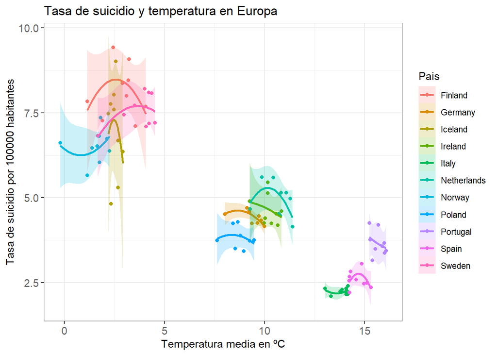

##### Paises_Separados

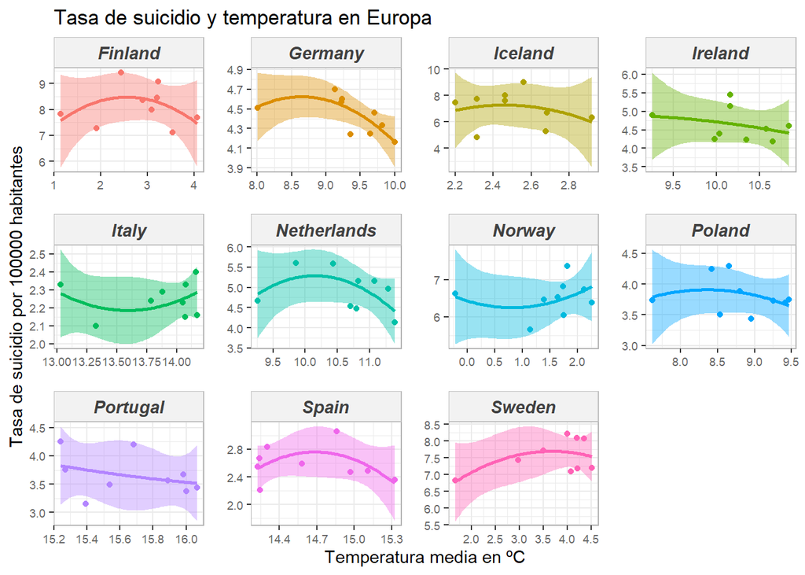

## Objetivo 2: Industrialización y emisión de CO2.

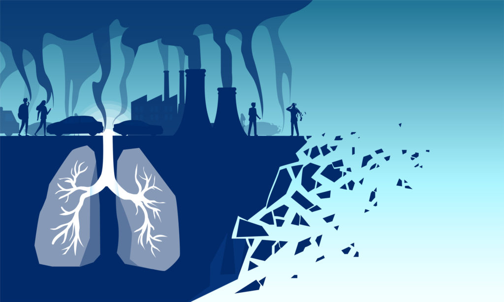

La hipótesis inicial es que aquellos países cuya industria tiene un peso considerable, tendrán tasas de emisión superiores.

## Objetivo 3: Sectores de empleo y suicidio.

Estudio del aumento o disminución de la tasa de suicidos en países europeos según la evolución del porcentaje de empleo en cada sector de trabajo.  
Parece más apropiado evaluar los datos de mujeres y hombres por separado ya que existe una gran diferencia entre las tasas de suicidio de unos y otros, siendo mucho mayor la de los hombres.

|  | Pais | Año | Empleo_Agricultura | Empleo_Industria | Empleo_Servicios | Region | Sexo | Tasa_suicidio |
| --- | --- | --- | --- | --- | --- | --- | --- | --- |
| 1 | Albania | 2013 | 44.20000076 | 16.87999916 | 38.91999817 | Europe | Female | 3.23 |
| 2 | Albania | 2013 | 44.20000076 | 16.87999916 | 38.91999817 | Europe | Both sexes | 4.84 |
| 3 | Albania | 2013 | 44.20000076 | 16.87999916 | 38.91999817 | Europe | Male | 6.53 |
| 4 | Armenia | 2013 | 36.27999878 | 17 | 46.72000122 | Europe | Female | 3.72 |
| 5 | Armenia | 2013 | 36.27999878 | 17 | 46.72000122 | Europe | Both sexes | 5.31 |
| 6 | Armenia | 2013 | 36.27999878 | 17 | 46.72000122 | Europe | Male | 7.15 |
| 7 | Austria | 2013 | 4.579999924 | 25.90999985 | 69.51999664 | Europe | Both sexes | 11.45 |
| 8 | Austria | 2013 | 4.579999924 | 25.90999985 | 69.51999664 | Europe | Male | 17.97 |
| 9 | Austria | 2013 | 4.579999924 | 25.90999985 | 69.51999664 | Europe | Female | 5.54 |
| 10 | Azerbaijan | 2013 | 37.09999847 | 14.38000011 | 48.52000046 | Europe | Female | 1.63 |

[output cut: 140 more lines]

#### Elige visualización

##### Mujeres

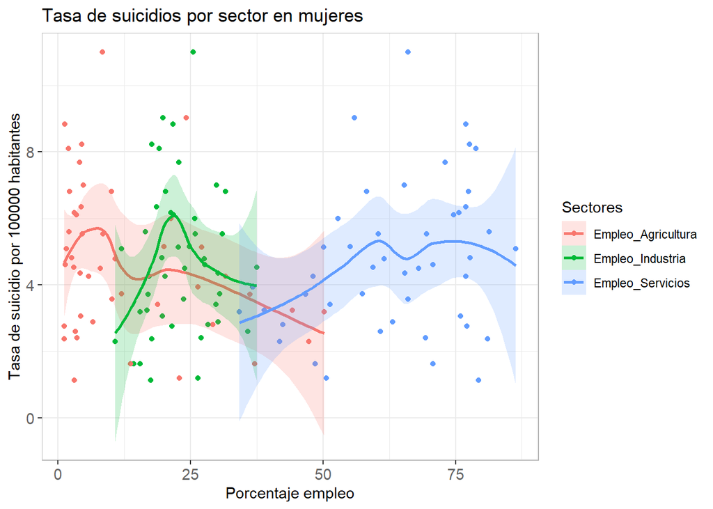

##### Hombres

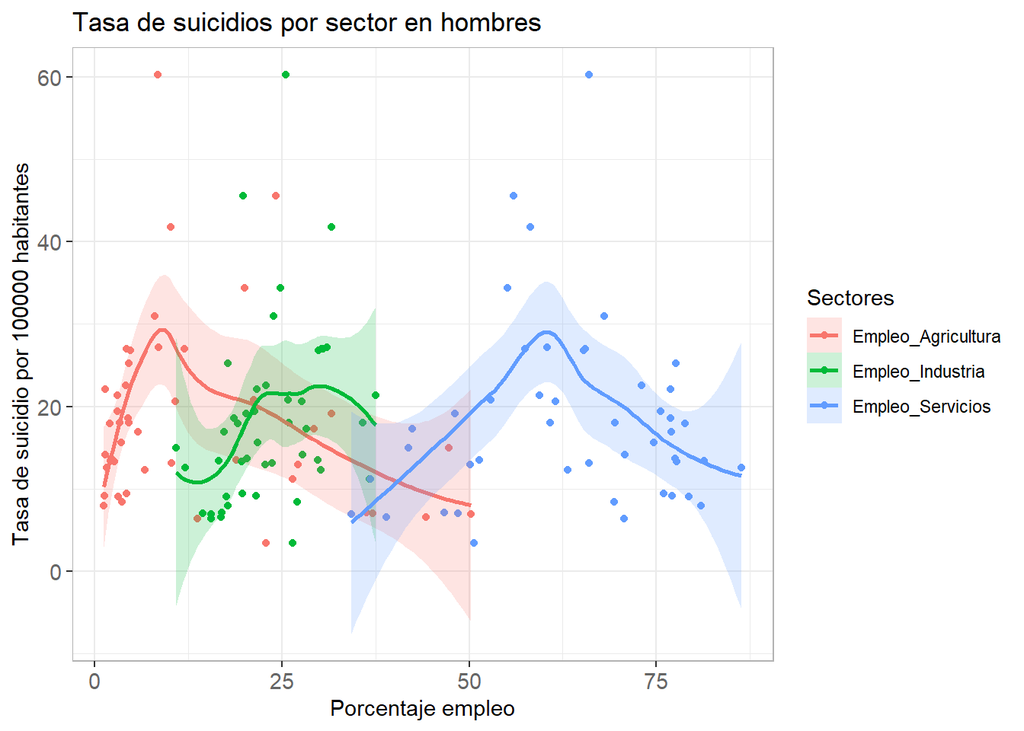

#### **Conclusiones**

Realizaremos el análisis de las gráficas según cada sector de empleo ya que con los datos de los que disponemos no es muy adecuado que el análisis sea conjunto.

- **Agricultura.**  
  En relación con la agricultura vemos cómo en ambas gráficas ante un mayor porcentaje de agricultores en la población trabajadora, se ve reducida la tasa de suicidio.
- **Industria.**
  - En mujeres se puede apreciar un pico según aumentan los niveles de industria del país, pero tras llegar a un determinado punto la tasa de suicidios vuelve a descender hasta alcanzar lo que parece una estabilidad.
  - En hombres hay también un ascenso en la tasa de suicidios pero no se produce ningún pico, sino que tras el ascenso se mantendrá bastante estable.
- **Servicios.**
  - En mujeres se produce un aumento de suicidios al mismo tiempo que el país incrementa el porcentaje de empleo en servicios, pero no se produce un pico escesivo y parece que se mantendrá más o menos estable.
  - En hombres con el aumento del porcentaje de empleo en servicios se va a producir un pico en la tasa de suicidios y cuando el país alcance un determinado desarrollo en este sector el pico descenderá y se producirá una posterior estabilidad en los suicidios.

Observación: parece que forma de la línea de industria en mujeres se intercambia por la de servicios en hombres y lo mismo sucede con la de servicios en mujeres e industria en hombres.

## Objetivo 4: Emisiones de CO2 y temperatura.

Evaluación de variaciones de emisiones de CO2 y su impacto en la temperatura media de una región/país.  
Se representarán los datos de emisiones medias y temperatura media del mundo para ver la comparación entre el análisis global y la local de un país determinado.

En este objetivo volvemos a trabajar con las tablas del inicio para poder visualizar las gráficas con una cantidad mayor de años, hemos seleccionado años desde 1970 hasta el 2013.

La siguiente tabla, que contiene información conjunta sobre el clima y las emisiones de CO2 por países, permitirá la correcta representación de las gráficas de las que se obtendrán las conclusiones.

|  | Pais | Año | CO2_T | Valores |
| --- | --- | --- | --- | --- |
| 1 | Afghanistan | 1970 | Emisiones_Anuales | 1670397 |
| 2 | Afghanistan | 1970 | Temperatura_Media | 14.7830833333333 |
| 3 | Afghanistan | 1971 | Emisiones_Anuales | 1893554 |
| 4 | Afghanistan | 1971 | Temperatura_Media | 14.8235 |
| 5 | Afghanistan | 1972 | Emisiones_Anuales | 1530347 |
| 6 | Afghanistan | 1972 | Temperatura_Media | 12.5471666666667 |
| 7 | Afghanistan | 1973 | Emisiones_Anuales | 1635454 |
| 8 | Afghanistan | 1973 | Temperatura_Media | 14.2355 |
| 9 | Afghanistan | 1974 | Emisiones_Anuales | 1913152 |
| 10 | Afghanistan | 1974 | Temperatura_Media | 13.31675 |

[output cut: 19864 more lines]

Para realizar la gráfica de emisiones mundiales, necesitamos modificar la tabla obtenida anteriormente, de la siguiente forma:

```r
CC_Mundo<- CC %>%
  group_by(Año)%>%
  summarise(Emisiones_Mundo= mean(Emisiones_Anuales, na.rm=TRUE), Temperatura_Mundo= mean(Temperatura_Media, na.rm= TRUE))
```

Obtenemos la siguiente tabla con la que podemos trabajar

|  | Año | Emisiones_Mundo | Temperatura_Mundo |
| --- | --- | --- | --- |
| 1 | 1970 | 269259402.247706 | 18.8728816029144 |
| 2 | 1971 | 278961065.232877 | 18.6538128415301 |
| 3 | 1972 | 290096115.204545 | 18.7511145833333 |
| 4 | 1973 | 306682270.242009 | 18.9666951992754 |
| 5 | 1974 | 306307276.794521 | 18.6943903985507 |
| 6 | 1975 | 307414748.369863 | 18.840933423913 |
| 7 | 1976 | 324679038.159817 | 18.5342989130435 |
| 8 | 1977 | 332737648.716895 | 19.013902173913 |
| 9 | 1978 | 342957203.018265 | 18.8162423007246 |
| 10 | 1979 | 352825901.506849 | 19.0332051630435 |

[output cut: 34 more lines]

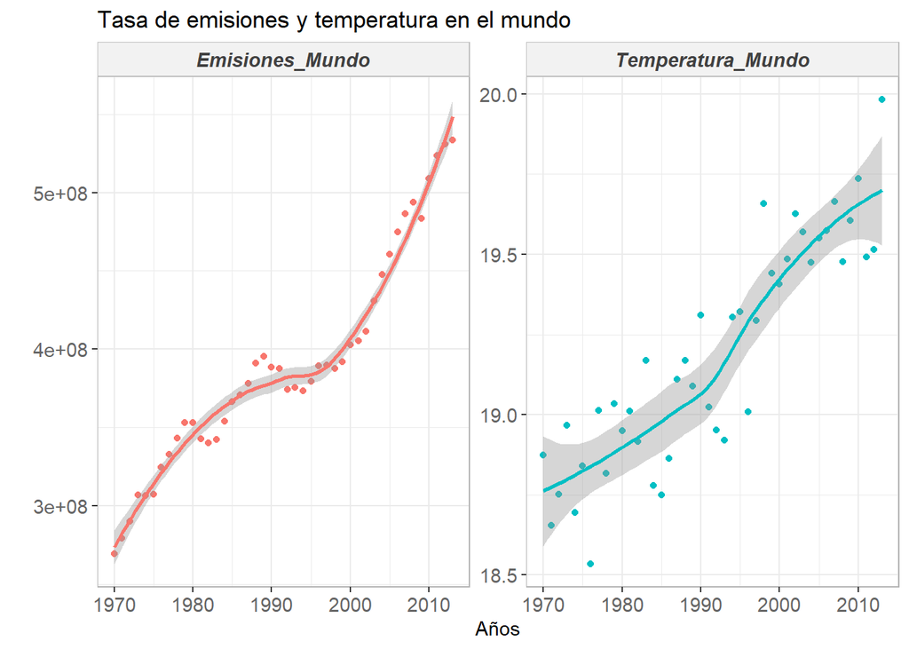

#### Selecciona un país

##### España

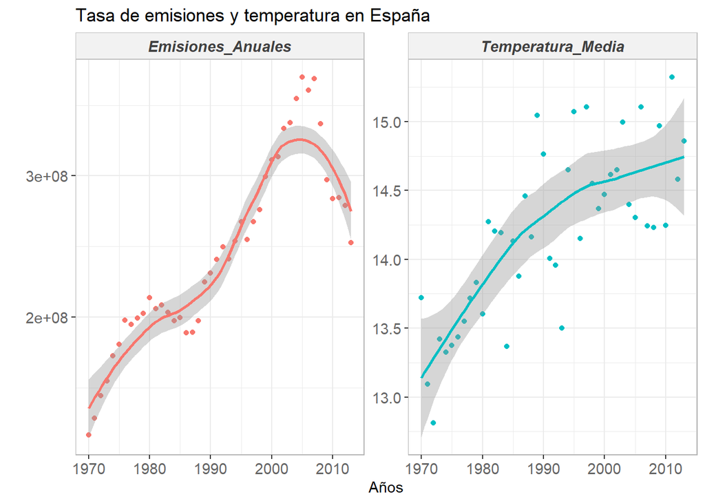

##### India

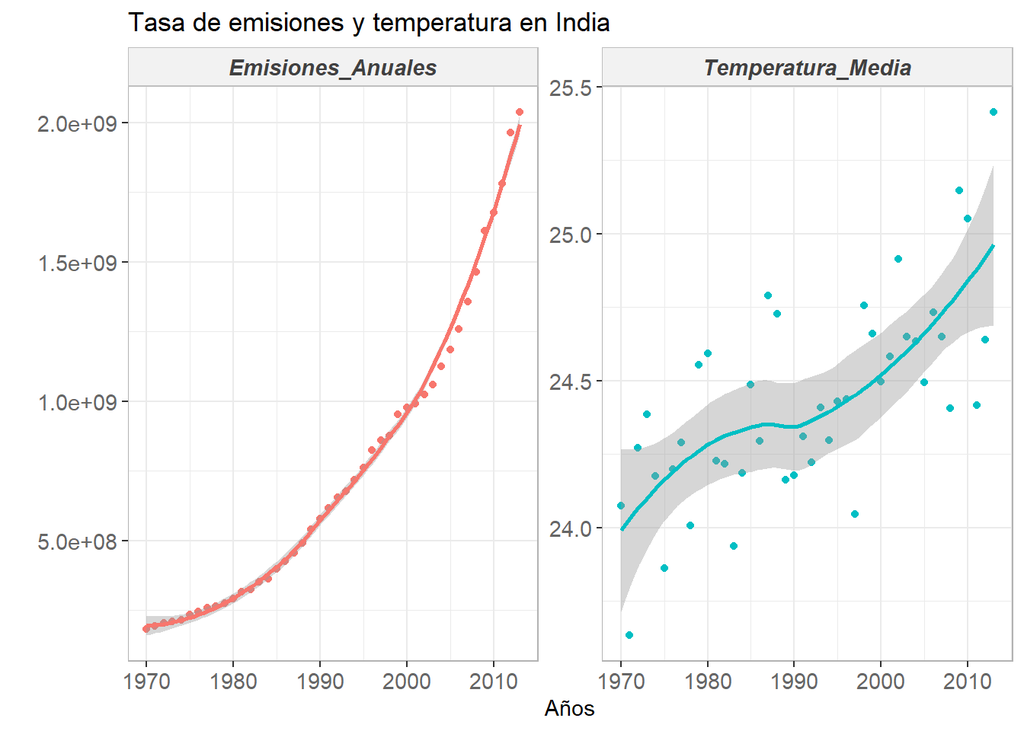

##### Senegal

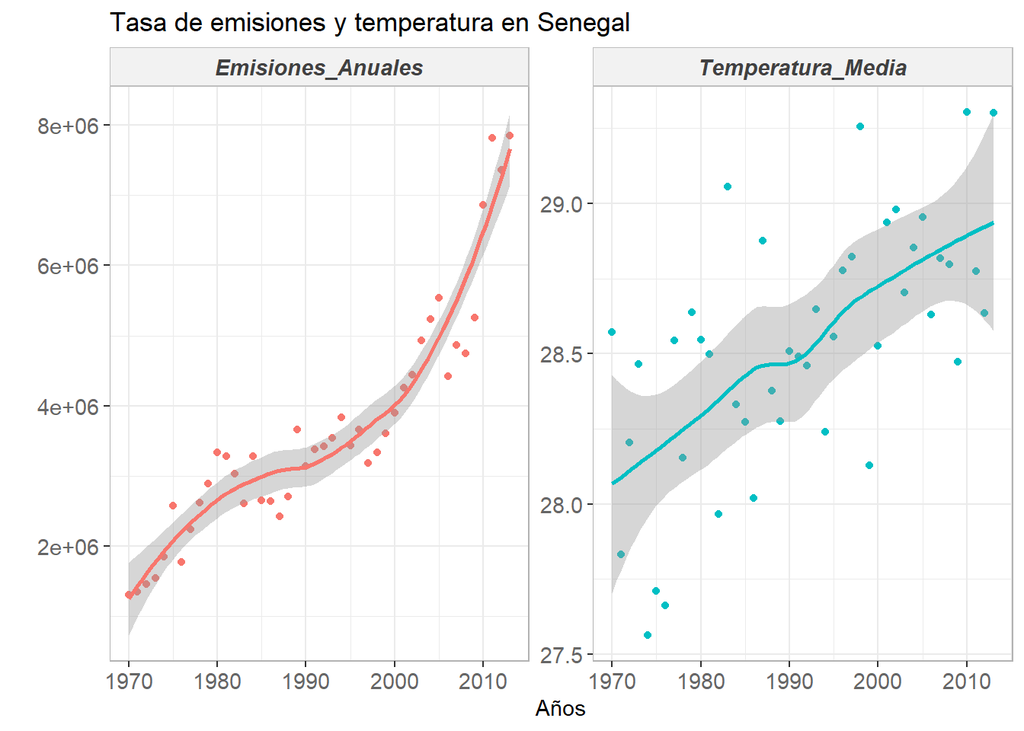

##### China

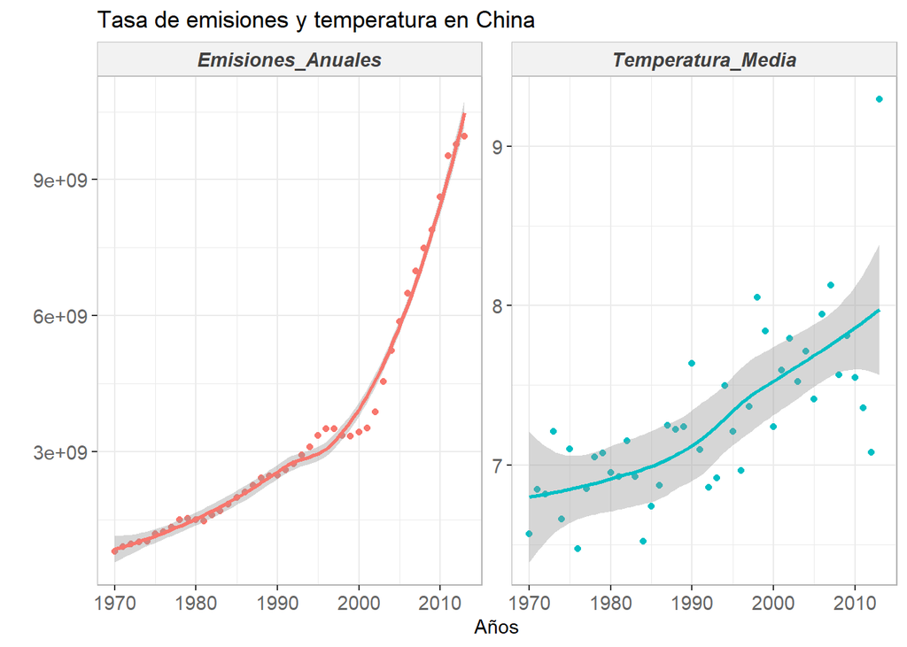

##### Canadá

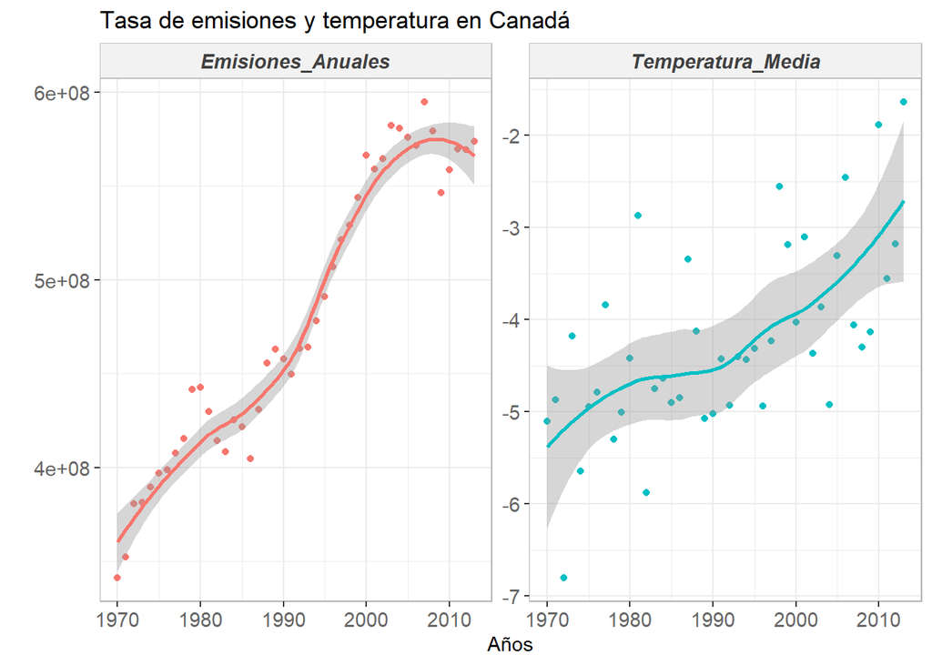

##### Japón

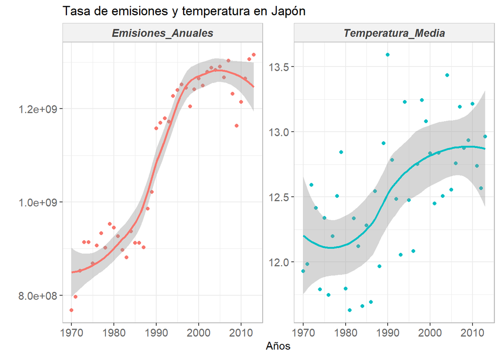

# 4. Bibliografía

1. Berkeley Earth. (s/f). Climate change: Earth surface temperature data [Data set]. Recuperado de https://www.kaggle.com/berkeleyearth/climate-change-earth-surface-temperature-data
2. Suicide rates. (s/f). Who.int. Recuperado de https://www.who.int/data/gho/data/themes/mental-health/suicide-rates
3. Annual CO₂ emissions. (s/f). Ourworldindata.org. Recuperado de https://ourworldindata.org/grapher/annual-co2-emissions-per-country?tab=table&time=latest
4. Share of employment in agriculture, industry, and services. (s/f). Ourworldindata.org. Recuperado de https://ourworldindata.org/grapher/share-of-employment-in-agriculture-industry-and-services?time=2014..latest